# Analysis - Franklin Glance

```r
# creating vector of companies who have been in the top 100 the whole time
top_100_vector = c(t(top_100))
```

Creating data frame with top companies from 2021 over the entire timeframe. Good subset of “successful” businesses.

```r
top_100_companies_long_term <- fortune_joined %>%
  group_by(Company) %>%
  filter(Year > 1985) %>%
  filter(n() > 35) %>%
  filter(Company %in% top_100_vector)
```

This isn’t a great visualization, however it does show that these companies as a whole experienced growth over the years.

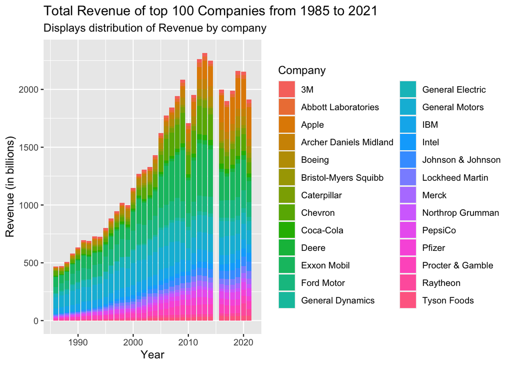

```r
top_100_companies_long_term %>%
  group_by(Company) %>%
  ggplot(aes(Year, Revenue)) +
  geom_col(aes(fill = Company)) +
  labs(title = "Total Revenue of top 100 Companies from 1985 to 2021",
       subtitle = "Displays distribution of Revenue by company") +
  ylab("Revenue (in billions)")
```

Top 100 revenue by sector. This is a very useful visualization, as it shows how some sectors have grown (technology, aerospace and defense), and others have diminished (motor vehicles and parts)

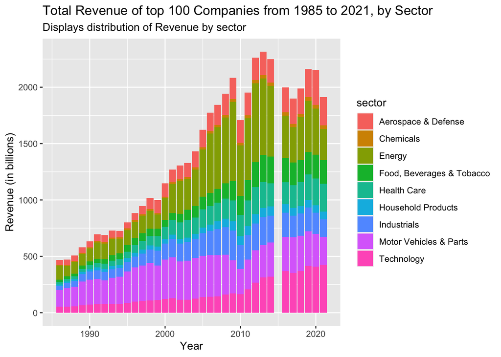

```r
top_100_companies_long_term %>%
  group_by(Company) %>%
  ggplot(aes(Year, Revenue)) +
  geom_col(aes(fill = sector)) +
  labs(title = "Total Revenue of top 100 Companies from 1985 to 2021, by Sector",
       subtitle = "Displays distribution of Revenue by sector") +
  ylab("Revenue (in billions)")
```

Let us visualize the same thing, but for all companies on the fortune 500 since 1985.

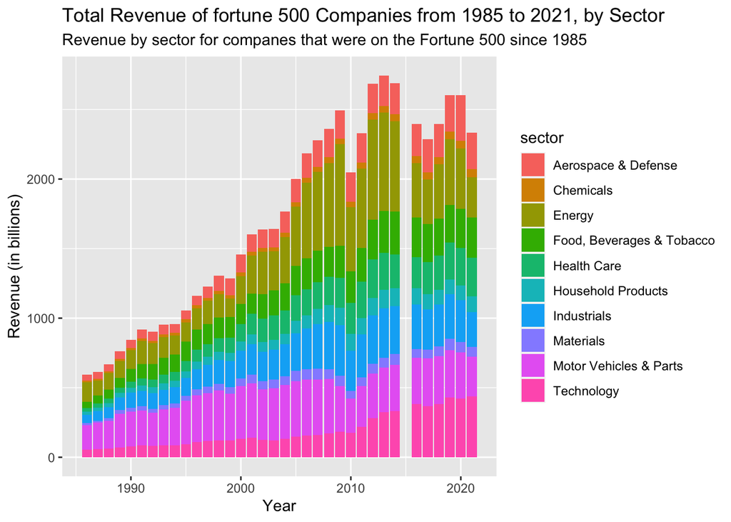

```r
fortune_joined %>%
  group_by(Company) %>%
  filter(Year > 1985) %>%
  filter(n() > 35) %>%
  ggplot(aes(Year, Revenue)) +
  geom_col(aes(fill = sector)) +
  labs(title = "Total Revenue of fortune 500 Companies from 1985 to 2021, by Sector",
       subtitle = "Revenue by sector for companes that were on the Fortune 500 since 1985") +
  ylab("Revenue (in billions)")
```

These graphs are helpful, however i think one focusing on the sectors could provide more useful insights.

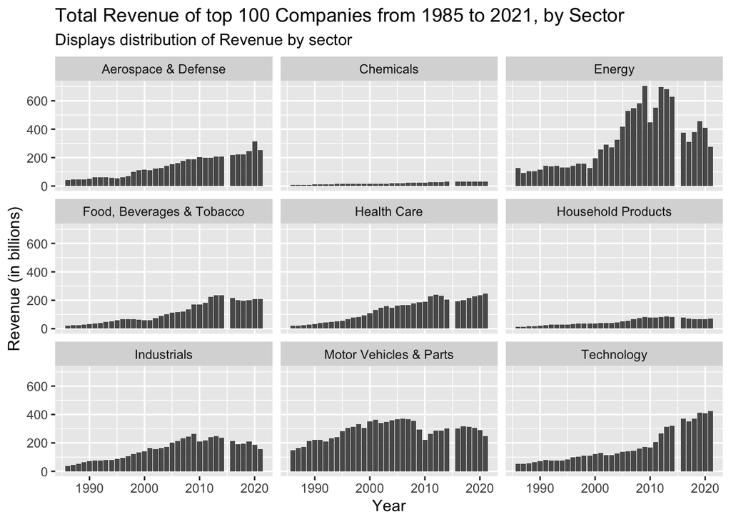

```r
top_100_companies_long_term %>%
  group_by(Company) %>%
  filter(Year > 1985) %>%
  filter(n() > 35) %>%
  group_by(Year, sector) %>%
  summarise(revenue_per_year = sum(Revenue)) %>%
  ggplot(aes(Year, revenue_per_year)) +
  geom_col() +
  facet_wrap(~ sector) +
  labs(title = "Total Revenue of top 100 Companies from 1985 to 2021, by Sector",
       subtitle = "Displays distribution of Revenue by sector") +
  ylab("Revenue (in billions)")
```

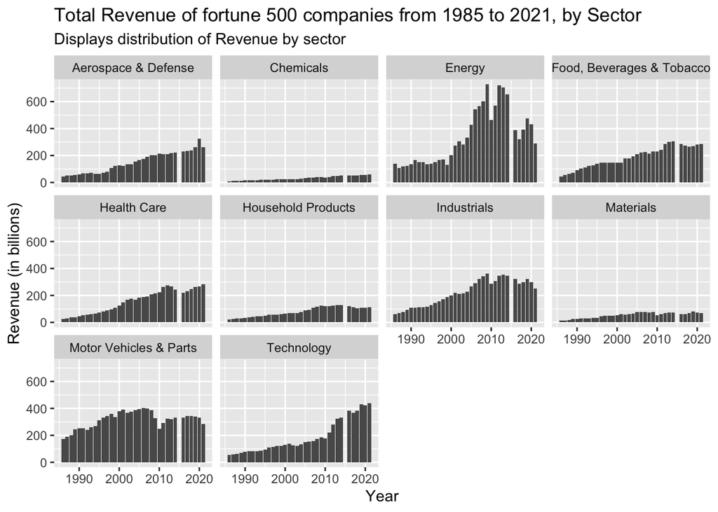

```r
fortune_joined %>%
  group_by(Company) %>%
  filter(Year > 1985) %>%
  filter(n() > 35) %>%
  group_by(Year, sector) %>%
  summarise(revenue_per_year = sum(Revenue)) %>%
  ggplot(aes(Year, revenue_per_year)) +
  geom_col() +
  facet_wrap(~ sector) +
  labs(title = "Total Revenue of fortune 500 companies from 1985 to 2021, by Sector",
       subtitle = "Displays distribution of Revenue by sector") +
  ylab("Revenue (in billions)")
```

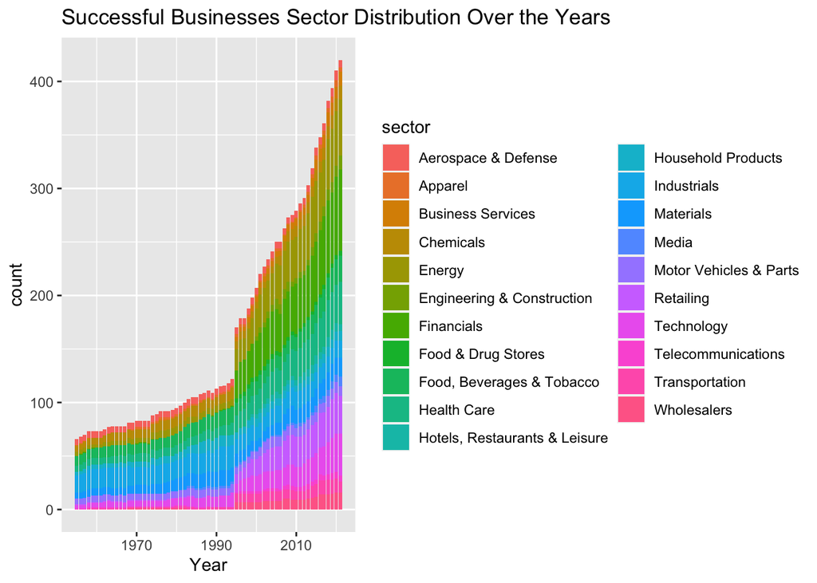

```r
fortune_joined %>%
  group_by(Year, sector) %>%
  ggplot(aes(Year)) +
  geom_bar(aes(fill = sector)) +
  labs(title = "Successful Businesses Sector Distribution Over the Years")
```

The previous analysis has aided in determining the following insights about fortune 500 companies. - There is a correlation between rank and revenue - Good subset of Companies to analyze are the top 100 companies from 2021, those of which have been on the fortune 500 since 1985. These can be our subset of “successful businesses” - We can visualize the breakdown of successful businesses by sector, which provides a good look into which sectors have grown/shrunk since 1985.

### Alternate subset of successful businesses (new additions to fortune 500 since 2000).

```r
new_additions <- fortune_joined %>%
  group_by(Company) %>%
  filter(Year > 2000) %>%
  filter(n() > 20) %>%
  group_by(Company) %>%
  filter(Year == 2021) %>%
  summarise(Company)
```

## Effects of Technology on Successful Businesses

Now we will explore potential relationships between emerging technologies and successful businesses.

#### Technology Adoption by Househods in the US.

[output not shown]

```r
technology_adoption_by_households_in_the_united_states %>%
  group_by(`Entity`) %>%
  filter(Year > 1985) %>%
  summarise(mean_diffusion_by_entity = mean(`Technology Diffusion (Comin and Hobijn (2004) and others)` )) %>%
  arrange(desc(mean_diffusion_by_entity))
```

```
## # A tibble: 36 × 2
##    Entity                                 mean_diffusion_by_entity
##    <chr>                                                     <dbl>
##  1 Electricity access                                        100
##  2 Flush toilet                                              100
##  3 Running water                                             100
##  4 Electric power                                             99
##  5 Radio                                                      99
##  6 Stove                                                      99.0
##  7 Household refrigerator                                     98.9
##  8 Television                                                 96.0
##  9 Colour TV                                                  94.6
## 10 Shipping container port infrastructure                     92
## # … with 26 more rows
```

Graphing just the top entities

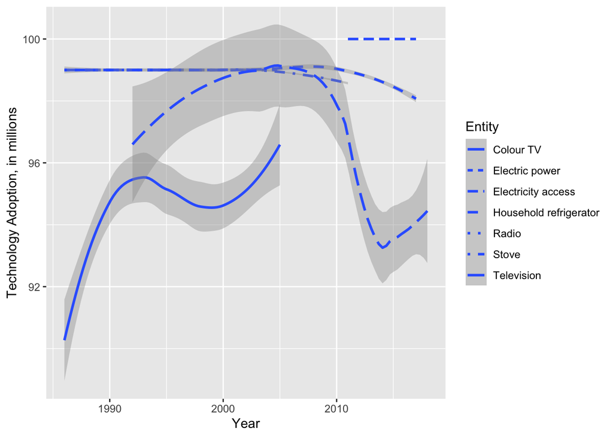

```r
technology_adoption_by_households_in_the_united_states %>%
  group_by(`Entity`) %>%
  filter(Year > 1985) %>%
  mutate(mean_diffusion_by_entity = mean(`Technology Diffusion (Comin and Hobijn (2004) and others)` )) %>%
  filter(mean_diffusion_by_entity > 92) %>%
  ggplot(aes(Year, `Technology Diffusion (Comin and Hobijn (2004) and others)`)) +
  geom_smooth(aes(linetype = `Entity`)) +
  ylab("Technology Adoption, in millions")
```

#### Supercomputer power, 1993 to 2021:

In itself, the doubling of transistors every two years does not directly matter as much as how those changes apply to computing power.

Insights: - the period of most rapid change in supercomputer power occurred from 2012 to 2021. This could be a good time frame to analyze the growth of tech succsessful businesses vs other successful businesses.

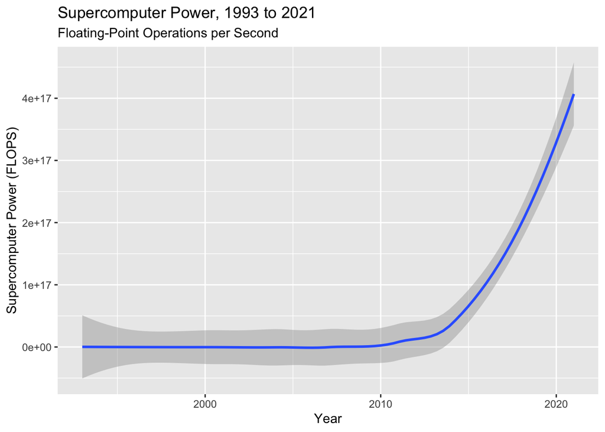

```r
supercomputer_power_flops %>%
  group_by(Year) %>%
  ggplot(aes(Year, `Floating-Point Operations per Second`)) +
  geom_smooth() +
  labs(title = "Supercomputer Power, 1993 to 2021",
       subtitle = "Floating-Point Operations per Second") +
  ylab("Supercomputer Power (FLOPS)")
```

#### Computing efficiency, 1985 to 2015:

The cost to keep the machine running also matters. Computing efficiency measures the computational capacity per unit of energy. In this chart we see the computing efficiency of various processors over time. Here, computing efficiency is measured as the number of watts (a measure of electrical power) needed to carry out a million instructions per second (Watts per MIPS).

Insights: - the period of most rapid change in computing efficiency was during the time frame of 1990 to 2000. This could be a good time frame to analyze the growth of tech succsessful businesses vs other successful businesses.

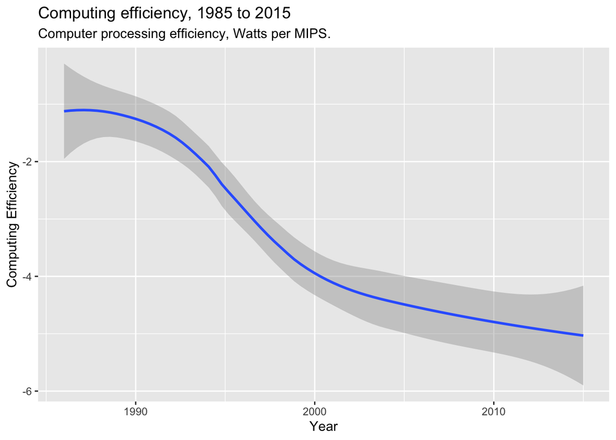

```r
computing_efficiency %>%
  group_by(Year) %>%
  filter(Year > 1985) %>%
  ggplot(aes(Year, log10(`Computing efficiency`))) +
  geom_smooth() +
  labs(title = "Computing efficiency, 1985 to 2015",
       subtitle = "Computer processing efficiency, Watts per MIPS.") +
  ylab("Computing Efficiency")
```

### Internet Usage, 1990 - 2019

While computing efficiency and supercomputer power directly relate to the power of tech, the adoption of tech is also very important. To understand this, we will look at data regarding the percentage of people in the US using the internet

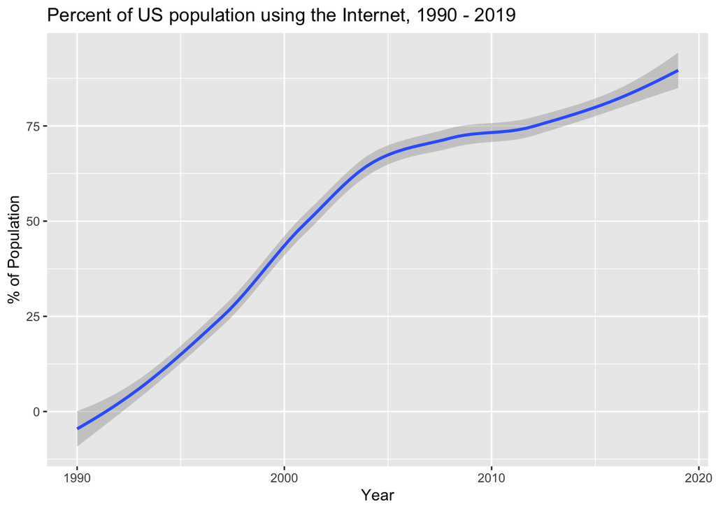

```r
percent_using_internet %>%
  ggplot(aes(Year, `Individuals using the Internet (% of population)`)) +
  geom_smooth() +
  labs(title ="Percent of US population using the Internet, 1990 - 2019") + ylab("% of Population")
```

### Phone Usage, 1985 - 2019

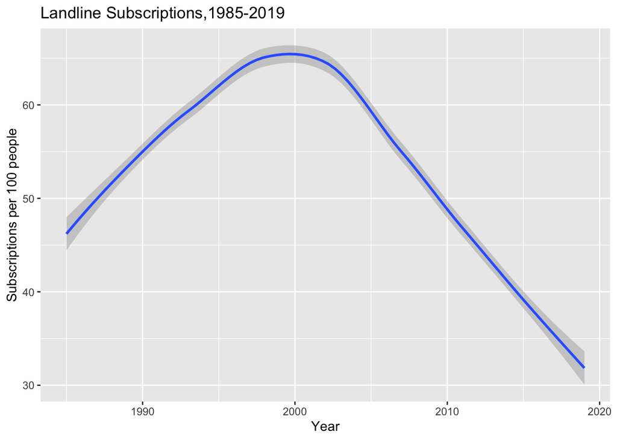

```r
landline_cellular_data %>%
  ggplot(aes(Year, `Landline Subscriptions (per 100 people)`)) +
  geom_smooth() +
  labs(title = "Landline Subscriptions,1985-2019") +
  ylab("Subscriptions per 100 people")
```

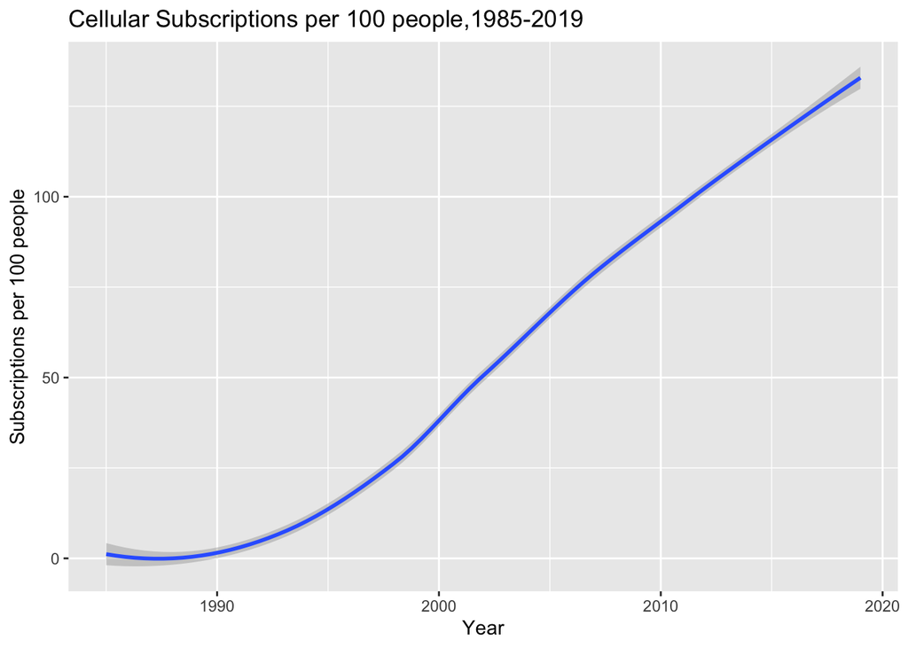

```r
landline_cellular_data %>%
  ggplot(aes(Year, `Cellular Subscriptions (per 100 people)`)) +
  geom_smooth() +
  labs(title = "Cellular Subscriptions per 100 people,1985-2019") +
  ylab("Subscriptions per 100 people")
```

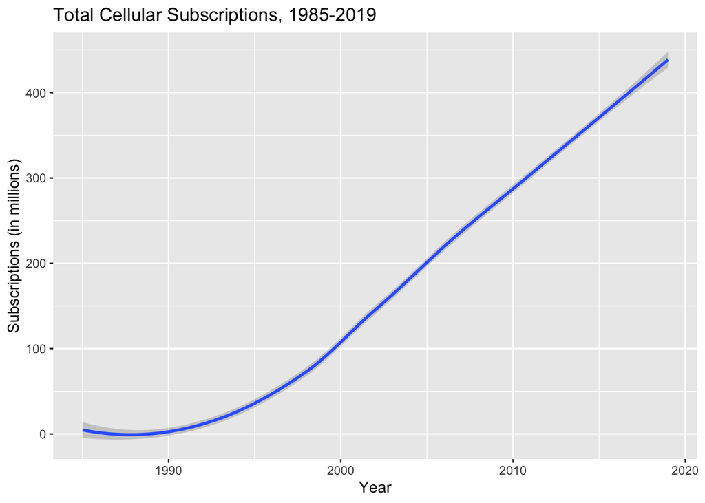

```r
landline_cellular_data %>%
  ggplot(aes(Year, `Cellular Subscriptions`/1000000)) +
  geom_smooth() +
  labs(title = "Total Cellular Subscriptions, 1985-2019") +
  ylab("Subscriptions (in millions)")
```

## Analysis of Relationship between Business Success and Technological Advancements/Adoption

### Relationship betweeen top 100 companies and tech advancements

joining datasets by year

```r
top_100_joined <- top_100_companies_long_term %>%
  left_join(landline_cellular_data, by = "Year") %>%
  left_join(percent_using_internet, by = "Year") %>%
  left_join(technology_adoption_by_households_in_the_united_states, by = "Year") %>%
  left_join(computing_efficiency, by = "Year") %>%
  left_join(supercomputer_power_flops, by = "Year")
```

All sectors

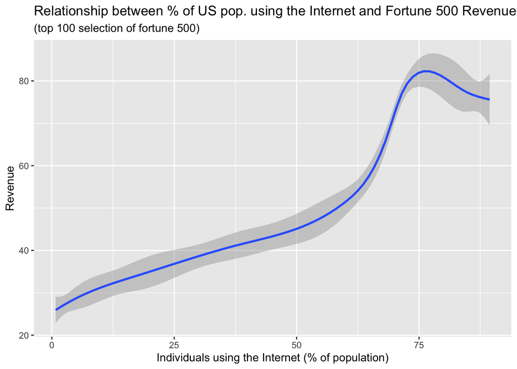

```r
top_100_joined %>%
  ggplot(aes(`Individuals using the Internet (% of population)`, Revenue)) +
  geom_smooth() +
  labs(title = "Relationship between % of US pop. using the Internet and Fortune 500 Revenue",
       subtitle ="(top 100 selection of fortune 500)")
```

Tech sectors

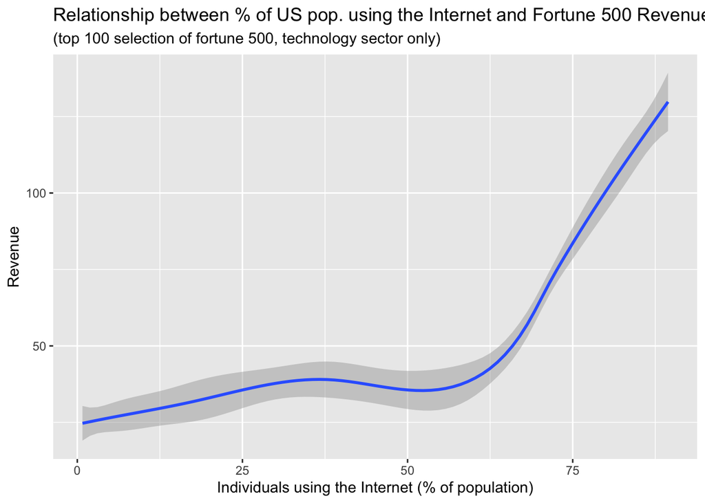

```r
top_100_joined %>%
  filter(sector == "Technology") %>%
  ggplot(aes(`Individuals using the Internet (% of population)`, Revenue)) +
  geom_smooth() +
    labs(title = "Relationship between % of US pop. using the Internet and Fortune 500 Revenue",
       subtitle ="(top 100 selection of fortune 500, technology sector only)")
```

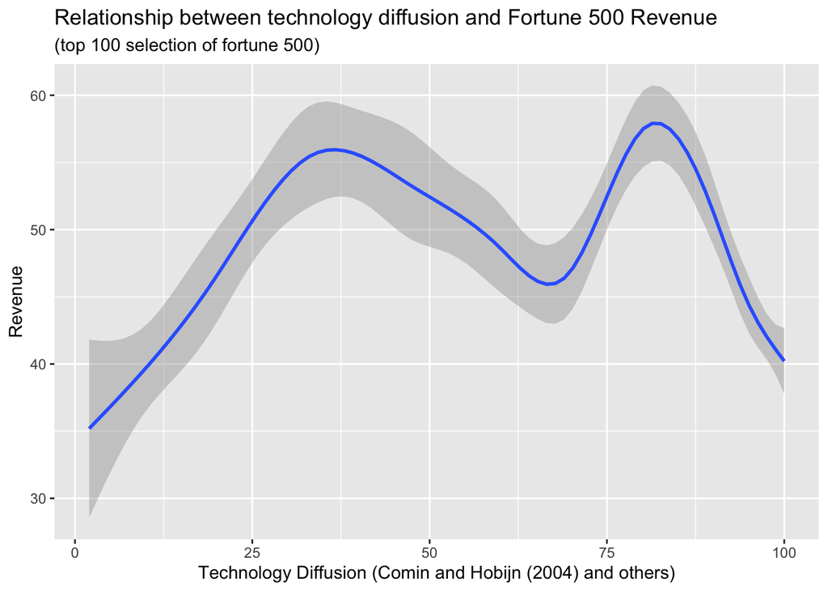

```r
top_100_joined %>%
  ggplot(aes(`Technology Diffusion (Comin and Hobijn (2004) and others)`, Revenue)) +
  geom_smooth() +
    labs(title = "Relationship between technology diffusion and Fortune 500 Revenue",
       subtitle ="(top 100 selection of fortune 500)")
```

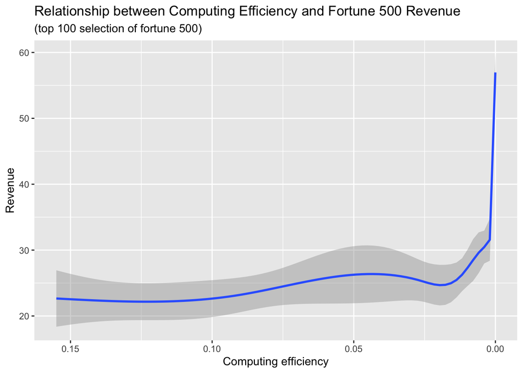

```r
top_100_joined %>%
  ggplot(aes(`Computing efficiency`, Revenue)) +
  geom_smooth() +
    labs(title = "Relationship between Computing Efficiency and Fortune 500 Revenue",
       subtitle ="(top 100 selection of fortune 500)") +
    scale_x_continuous(trans = "reverse")
```